# Trabalho prático Iteração e Concorrência

Grupo 21:

- Eduardo Pereira
- João Coutinho

## 0. Introdução

O objetivo deste trabalho é implementar um algoritmo em qiskit para encontrar **S** numa lista tal que:
$$ S = N mod 8$$

## 1. Implementação do algoritmo

Tratando-se da essencia deste algoritmo uma procura de uma solução numa lista, decidimos seguir o algoritmo de Grover lecionado na aula pratica 4.  
Em 1996 *Lov Grover* apresentou um algoritmo para resolver o problema de pesquisa rápida numa base de dados.  
O algoritmo também pode ser utilizado como truque geral ou subrotina de modo a obter melhorias de tempo de execução quadrático em outros algoritmos.

No caso geral do algoritmo de Grover, temos uma lista de 0 a N elementos, onde quermos encontrar o elemento **w**, tal que.

| $0$ | $0$ | $0$ |  | $1$ |  | $0$ | $0$ |
| --- | --- | --- | --- | --- | --- | --- | --- |
| $0$ | $1$ | $2$ | ... | $w$ | ... | $N-1$ | $N=2^n$ |

Como foi dito na introdução, vamos considerar uma lista com 8 elementos, de 0 a 7, isto é, $|000\rangle$ a $|111\rangle$. Onde queremos encontrar o número $|101\rangle$, tal que:

| $0$ | $0$ | $0$ | $0$ | $0$ | $1$ | $0$ | $0$ |  |  |  |  |  |  |  |  |
| --- | --- | --- | --- | --- | --- | --- | --- | --- | --- | --- | --- | --- | --- | --- | --- |
| $ | 000\rangle$ | $ | 001\rangle$ | $ | 010\rangle$ | $ | 011\rangle$ | $ | 100\rangle$ | $ | 101\rangle$ | $ | 110\rangle$ | $ | 111\rangle$ |

Classicamente o pior caso deste algoritmo ocorre quando o valor desejado se encontra no ultimo elemento da lista, tendo assim custo $N$, no entando, no caso médio teria custo $N/2$.  
Computação quantica demonstra uma enorme vantangem, conseguindo realizar este algoritmo com um custo de $\sqrt{N}$. Para além disso, o algoritmo de Grover é genérico, pois não usa a estrura interna de lista.

Similarmente ao que acontece com o algoritmo de Deutsh-Jozsa, o algoritmo de Grover necessida de um Oráculo. Uma forma simples de codificar a função do Oráculo é: $$f(x)=0$$ $$f(w)=1$$
Onde, $w = |101\rangle \wedge x\in list \wedge x\not = |101\rangle$

##### Representação gráfica do funcionamento do algortimo de Grover:

[figure not shown]

Credit: C. Figgatt et al. Published in Nature Communications

O algortimo de Grover pode ser dividido em 3 fases:

- Inicialização;
- Oráculo;
- Amplificação

### 1.0. Imports, circuito quântico e barreiras

Antes de começar a implementação do algoritmo de Grover, faremos alguns imports, estabelecemos se queremos barreiras e criamos o circuito quântico.

```python
from qiskit import*
%matplotlib inline
from qiskit.tools.visualization import*

barrier = True

nqubits = 3

qc = QuantumCircuit(nqubits)
```

### 1.1 Inicialização

Devemos inicializar o sistema de modo que todos os estados de entrada possiveis têm a mesma amplitude.  
Para isso, vamo aplicar um gate de *Hadamar* a todos os qubits, Criando **sobreposição uniforme**.

Sabemos que o gate de *Hadamar* é:

| Gate Name | Syntax | Matrix | How is it implemented |
| --- | --- | --- | --- |
| Hadamard | qc.h(qr) | $ H =\frac{1}{\sqrt{2}}\begin{bmatrix} 1 & 1 \\ 1 & -1\end{bmatrix}$ | $u2(0,\pi)$ |

No caso geral a sobreposição é gerada da seguinte forma: $$|S\rangle = H^{\otimes n}|0\rangle ^{\otimes n} =\frac{1}{\sqrt N}\sum_{0}^{N-1}|x\rangle$$
Uma vez que estamos a trabalhar com 3 qubits, $n=3$ e $N= 2^3$.
Assim, aplicando Hadamar a todas as possibilidades de input, temos:

$$H³|000\rangle = \frac{1}{2\sqrt 2}|000\rangle + \frac{1}{2\sqrt 2}|001\rangle + \frac{1}{2\sqrt 2}|010\rangle + \frac{1}{2\sqrt 2}|011\rangle + \frac{1}{2\sqrt 2}|100\rangle + \frac{1}{2\sqrt 2}|101\rangle + \frac{1}{2\sqrt 2}|111\rangle $$

##### Representação gráfica:

[figure not shown]

Crédito: https://qiskit.org/textbook/ch-algorithms/grover.html

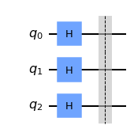

```python
qc = QuantumCircuit(nqubits)
for q in range (nqubits):
    qc.h(q)

if barrier:
    qc.barrier()

qc.draw(output='mpl')
```

### 1.2. Oráculo

O oráculo é responsável por descobrir a solução do problema neste caso $|101\rangle$, aplicando-lhe uma rotação de amplitude $\pi$ radianos, tornando a sua amplitude negativa, como exemplifica a seguinte imagem:

[figure not shown]

Crédito: https://qiskit.org/textbook/ch-algorithms/grover.html

Para definir o oráculo usamos o Pauli-X gate e o Toffoli gate (ccx)

[output not shown]

- O gate **Pauli-X** é um gate que atua sobre 1 qubit e aplica-lhe uma rotação de $\pi$ *rad* sobre o eixo do **X**, na esfera de *Bloch*. A sua equivalência na computação classica é um gate **NOT**.
- O gate de **Toffoli** também conhecido como *Controlled-Controlled-X* (**CCX**) é um gate que atua sobre 3 qubits, e aplica uma **NOT** no terceiro qubit se o primeiro e o segundo tiverem valor $|1\rangle$, caso contrario deixa-o inalterado. Pode ainda ser descrito como um gate que mapeia $|q1,q2,q3\rangle \mapsto |q1,q2,q3 \oplus (q1 \wedge q2)\rangle$.

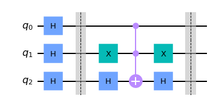

```python
qc.h(2)
qc.x(1)
qc.ccx(0,1,2)
qc.h(2)
qc.x(1)

if barrier:
    qc.barrier()

qc.draw(output='mpl')
```

```python
backend_state = Aer.get_backend('statevector_simulator') # the device to run on

result = execute(qc, backend_state).result()
psi2  = result.get_statevector(qc)
```

```python
psi2.real
```

```
array([ 0.35355339,  0.35355339,  0.35355339,  0.35355339,  0.35355339,
       -0.35355339,  0.35355339,  0.35355339])
```

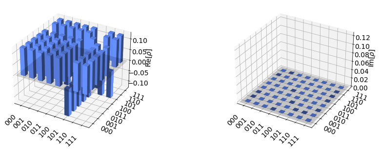

```python
plot_state_city(psi2)
```

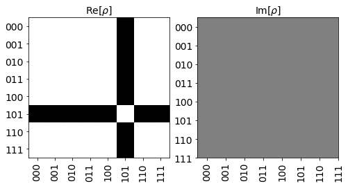

```python
plot_state_hinton(psi2)
```

### 1.3 Amplificação

[figure not shown]

Crédito: https://qiskit.org/textbook/ch-algorithms/grover.html

A implementação do processo de amplitude consiste na aplicação de gates *Hadamar* a todos os qubits seguido de gates *Pauli-X* , também a todos os qubits de seguida aplicamos o control gate *Z* que como sabemos no qiskit é representado por dois gates *Hadamar* intercalados por um gate de *Tuffoli*.

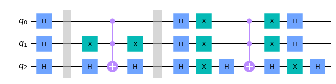

```python
for q in range(nqubits):
    qc.h(q)

for q in range(nqubits):
    qc.x(q)

qc.h(2)
qc.ccx(0,1,2)
qc.h(2)

for q in range(nqubits):
    qc.x(q)
    qc.h(q)

qc.draw(output='mpl')
```

Todo este processo deve ser aplicado varias vezes consoante o numero de inputs, de modo a otimizar a probabilidade de termos o resultado esperado.

[figure not shown]

Crédito: https://qiskit.org/textbook/ch-algorithms/grover.html

Como podemos ver na imagem, temos de aplicar o processo do oráculo e do amplificador $\sqrt{2^3}$ vezes:

```python
import math as m

m.sqrt(2**3)
```

```
2.8284271247461903
```

Uma vez que obtemos um valor entre 2 e 3, testamos qual seria a melhor opção. Verificamos que aplicando o processo 2 vezes a probabilidade de obter o valor esperado ( $|101\rangle$ ), era por volta de 90% enquando que aplicando 3 vezes esse valor rondava uns meros 30%.  
Optamos assim por aplicar o processo apenas 2 vezes.

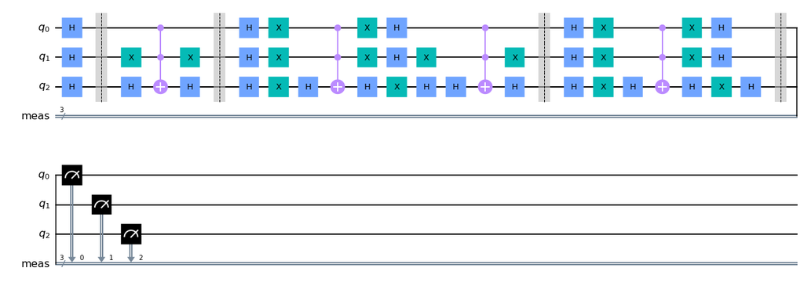

```python
qc.h(2)
qc.x(1)
qc.ccx(0,1,2)
qc.h(2)
qc.x(1)

if barrier:
    qc.barrier()

for q in range(nqubits):
    qc.h(q)
    qc.x(q)

qc.h(2)
qc.ccx(0,1,2)
qc.h(2)

for q in range(nqubits):
    qc.x(q)
    qc.h(q)

qc.measure_all()
qc.draw(output='mpl')
```

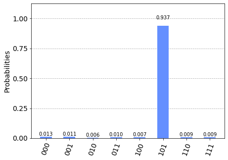

```python
backend = Aer.get_backend('qasm_simulator')

#Executa a lista de circuitos quânticos no backend e guarda o resultado
results = execute(qc, backend = backend, shots = 1024).result()

plot_histogram(results.get_counts(qc))
```

```python
#calcula a profundidade do circuito
qc.depth()
```

```
22
```

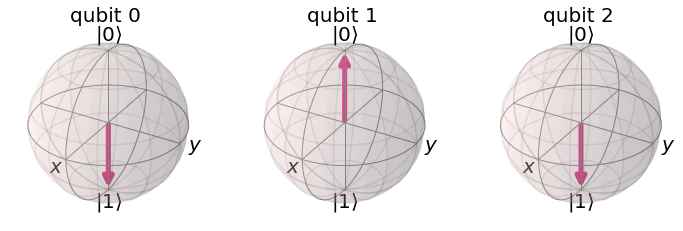

```python
backend_state = Aer.get_backend('statevector_simulator') # the device to run on

#Executa a lista de circuitos quânticos no backend e guarda o resultado
result = execute(qc, backend_state).result()

#Obtém o statevector final de um circuito quântico
psi2  = result.get_statevector(qc)

#Desenho das esferas de Bloch e as respetivas projeções em cada eixo
plot_bloch_multivector(psi2)
```

```python
psi2.real
```

```
array([-0., -0., -0., -0., -0.,  1., -0., -0.])
```

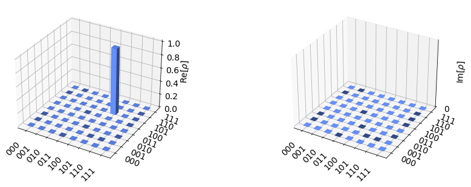

```python
plot_state_city(psi2)
```

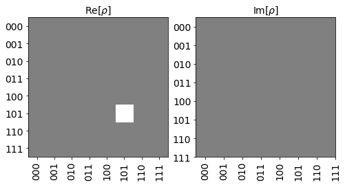

```python
plot_state_hinton(psi2)
```

## 3. Executar o algoritmo no IBM Q.

```python
from qiskit import IBMQ
from qiskit.providers.ibmq import least_busy
```

```python
# Carrega as informações da conta local e as respectivas máquinas associadas.
provider = IBMQ.load_account()
provider.backends()
```

```
[<IBMQSimulator('ibmq_qasm_simulator') from IBMQ(hub='ibm-q', group='open', project='main')>,
 <IBMQBackend('ibmqx2') from IBMQ(hub='ibm-q', group='open', project='main')>,
 <IBMQBackend('ibmq_16_melbourne') from IBMQ(hub='ibm-q', group='open', project='main')>,
 <IBMQBackend('ibmq_armonk') from IBMQ(hub='ibm-q', group='open', project='main')>,
 <IBMQBackend('ibmq_athens') from IBMQ(hub='ibm-q', group='open', project='main')>,
 <IBMQBackend('ibmq_santiago') from IBMQ(hub='ibm-q', group='open', project='main')>,
 <IBMQBackend('ibmq_lima') from IBMQ(hub='ibm-q', group='open', project='main')>,
 <IBMQBackend('ibmq_belem') from IBMQ(hub='ibm-q', group='open', project='main')>,
 <IBMQBackend('ibmq_quito') from IBMQ(hub='ibm-q', group='open', project='main')>,
 <IBMQSimulator('simulator_statevector') from IBMQ(hub='ibm-q', group='open', project='main')>,
 <IBMQSimulator('simulator_mps') from IBMQ(hub='ibm-q', group='open', project='main')>,
 <IBMQSimulator('simulator_extended_stabilizer') from IBMQ(hub='ibm-q', group='open', project='main')>,
 <IBMQSimulator('simulator_stabilizer') from IBMQ(hub='ibm-q', group='open', project='main')>,
 <IBMQBackend('ibmq_manila') from IBMQ(hub='ibm-q', group='open', project='main')>]
```

```python
# Backend overview
import qiskit.tools.jupyter
%qiskit_backend_overview
```

```python
from qiskit.tools.monitor import backend_overview, backend_monitor
#Fornece informações gerais de todos os backends do IBMQ que estão disponíveis
backend_overview()
```

```
ibmq_manila                  ibmq_quito                   ibmq_belem
-----------                  ----------                   ----------
Num. Qubits:  5              Num. Qubits:  5              Num. Qubits:  5
Pending Jobs: 8              Pending Jobs: 8              Pending Jobs: 0
Least busy:   False          Least busy:   False          Least busy:   True
Operational:  True           Operational:  True           Operational:  True
Avg. T1:      151.0          Avg. T1:      75.2           Avg. T1:      79.3
Avg. T2:      67.0           Avg. T2:      73.2           Avg. T2:      91.6



ibmq_lima                    ibmq_santiago                ibmq_athens
---------                    -------------                -----------
Num. Qubits:  5              Num. Qubits:  5              Num. Qubits:  5
Pending Jobs: 7              Pending Jobs: 1              Pending Jobs: 6
Least busy:   False          Least busy:   False          Least busy:   False
Operational:  True           Operational:  True           Operational:  True
Avg. T1:      69.2           Avg. T1:      136.2          Avg. T1:      95.9
Avg. T2:      64.9           Avg. T2:      136.4          Avg. T2:      120.6



ibmq_armonk                  ibmq_16_melbourne            ibmqx2
-----------                  -----------------            ------
Num. Qubits:  1              Num. Qubits:  15             Num. Qubits:  5
Pending Jobs: 27             Pending Jobs: 1              Pending Jobs: 1
Least busy:   False          Least busy:   False          Least busy:   False
Operational:  True           Operational:  True           Operational:  True
Avg. T1:      124.6          Avg. T1:      57.5           Avg. T1:      54.1
Avg. T2:      217.3          Avg. T2:      56.2           Avg. T2:      40.5
```

```python
#Seleciona uma máquina
backends_list =provider.backends( simulator=False, open_pulse=False)
backend_device = provider.get_backend('ibmq_belem')
print("Running on: ", backend_device)
```

```
Running on:  ibmq_belem
```

```python
#Obtém informação sobre o backend
backend_device
```

```
<IBMQBackend('ibmq_belem') from IBMQ(hub='ibm-q', group='open', project='main')>
```

```python
backend_monitor(backend_device)
```

[output not shown]

[output cut: 19 more lines]

[output not shown]

```python
%qiskit_job_watcher
```

```python
#Executa a lista de circuitos quânticos no backend e guarda o resultado
job_r = execute(qc, backend_device, shots=1024)
jobID_r = job_r.job_id()
print('JOB ID: {}'.format(jobID_r))
```

```
JOB ID: 60bba3ba1eb0247e23cee963
```

```python
#ibmq 1 times the oracle:
job_get=backend_device.retrieve_job(jobID_r)
result_r = job_get.result()
counts_run = result_r.get_counts(qc)
```

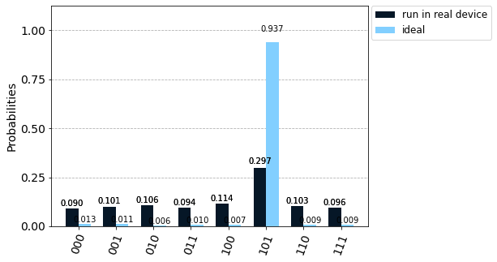

```python
plot_histogram([counts_run, results.get_counts(qc) ],
               legend=[ 'run in real device','ideal'], color=['#061727','#82cfff'])
```

### Optimização

Para tentar melhorar este circuito quântico vamos aplicar algumas otimizações utilizando transpilers. Os transpilers reduzem o tempo de execução do código originando um novo código otimizado. O novo código que o transpiler fornece como saída executa a mesma tarefa. Este novo código é equivalente e é mais eficiente de alguma forma em comparação com o código original. Na programação quântica, os transpilers são essenciais para melhorar o desempenho do hardware, pois reduzem o tempo de execução, e essa redução leva a diminuição de erros nos cálculos em computadores quânticos. Relativamente aos níveis de otimização temos 4 possíveis otimizações:

- **Otimização com nível 0:** apenas mapeia o circuito para o back-end, sem otimização explícita;
- **Otimização com nível 1:** mapeia o circuito, mas também faz otimizações leves ao fechar portas adjacentes;
- **Otimização com nível 2:** otimizações médias, incluindo um layout adaptável ao ruído e um procedimento de cancelamento de portas, a partir de relações de comutação das portas;
- **Otimização com nível 3:** otimização pesada, que, para além das etapas anteriores, faz a ressíntese de blocos de portas de dois qubit no circuito.

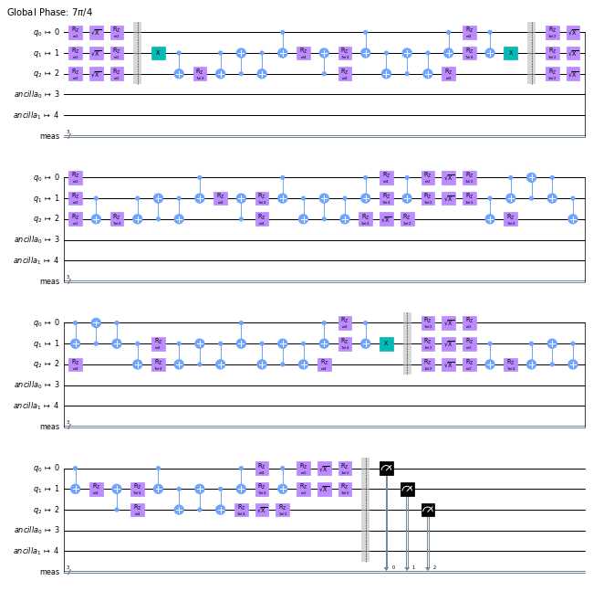

```python
from qiskit.compiler import transpile

qc_t_real = transpile(qc, backend=backend_device)

qc_t_real.draw(output='mpl', scale=0.5)
```

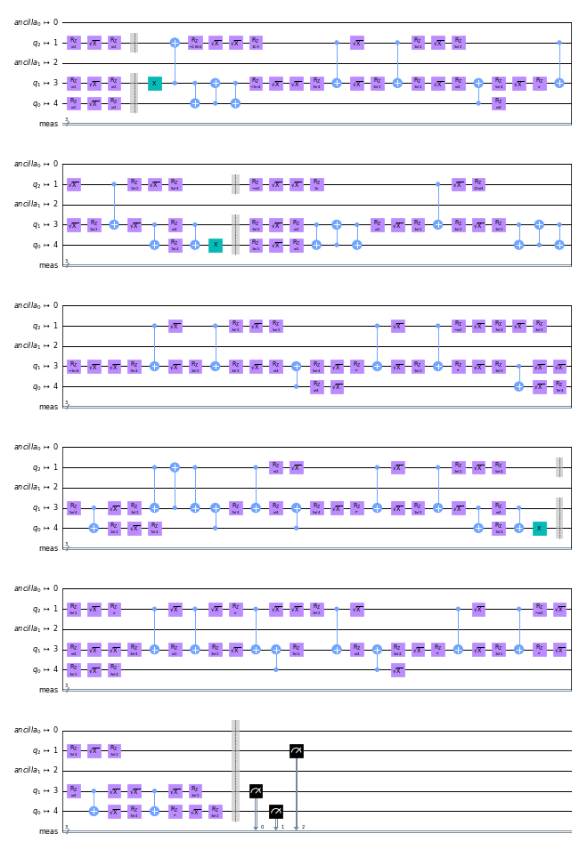

```python
qc_optimized3 = transpile(qc, backend=backend_device, optimization_level=3)
qc_optimized3.draw(output='mpl', scale=0.5)
```

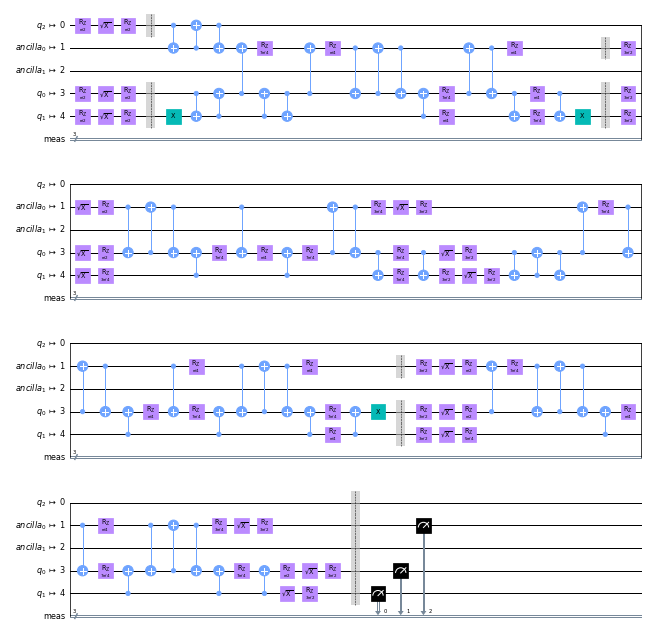

```python
qc_optimized2 = transpile(qc, backend=backend_device, optimization_level=2)
qc_optimized2.draw(output='mpl', scale=0.5)
```

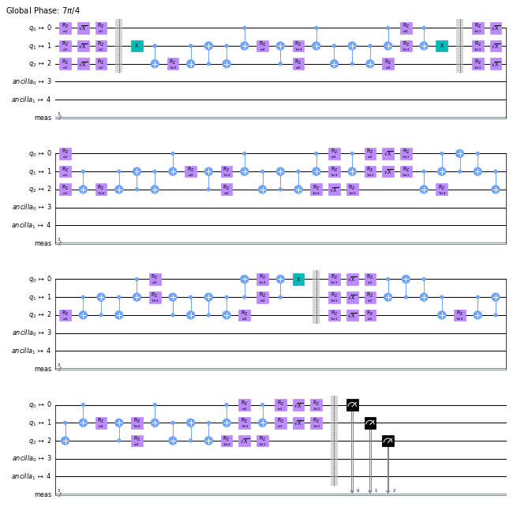

```python
qc_optimized1 = transpile(qc, backend=backend_device, optimization_level=1)
qc_optimized1.draw(output='mpl', scale=0.5)
```

```python
qc_optimized3.depth()
```

```
131
```

```python
qc_optimized2.depth()
```

```
85
```

```python
qc_optimized1.depth()
```

```
88
```

```python
job_exp = execute(qc_optimized3, backend_device, shots = 1024)
# job_id allows you to retrive old jobs
jobID = job_exp.job_id()
print('JOB ID: {}'.format(jobID))
job_exp.result().get_counts(qc_optimized3)
```

```
JOB ID: 60bba3dafe8ff1921b29e8d7
```

```
{'000': 101,
 '001': 117,
 '010': 83,
 '011': 72,
 '100': 97,
 '101': 376,
 '110': 87,
 '111': 91}
```

```python
job_get_o=backend_device.retrieve_job(jobID)
result_real_o = job_get_o.result(timeout=3600, wait=5)
counts_opt3 = result_real_o.get_counts(qc_optimized3)
```

```python
job_exp = execute(qc_optimized2, backend_device, shots = 1024)
# job_id allows you to retrive old jobs
jobID2 = job_exp.job_id()
job_get_o=backend_device.retrieve_job(jobID2)
result_real_o = job_get_o.result(timeout=3600, wait=5)
counts_opt2 = result_real_o.get_counts(qc_optimized2)
```

```python
job_exp = execute(qc_optimized1, backend_device, shots = 1024)
# job_id allows you to retrive old jobs
jobID1 = job_exp.job_id()
job_get_o=backend_device.retrieve_job(jobID1)
result_real_o = job_get_o.result(timeout=3600, wait=5)
counts_opt1 = result_real_o.get_counts(qc_optimized1)
```

```python
%qiskit_disable_job_watcher
```

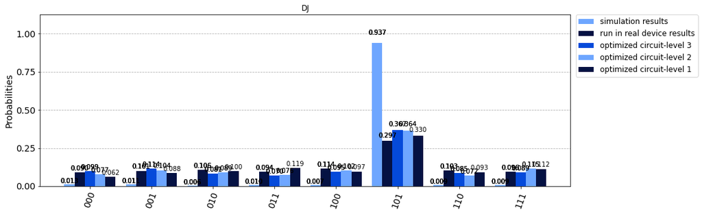

```python
title = 'DJ'
legend = [ 'simulation results','run in real device results','optimized circuit-level 3',
          'optimized circuit-level 2','optimized circuit-level 1']
color = ['#6ea6ff','#051243','#054ada']

plot_histogram([results.get_counts(qc), counts_run, counts_opt3, counts_opt2, counts_opt1],
               legend = legend, title= title, color=color, figsize=(15, 5))
```

## 4. Tratamento e mitigação de erros com recuso ao Ignis Framework

Como sabemos os sistemas quânticos estão sujeitos a alguns erros, estes erros são causados pelo chamado **Ruído**. Estes erros acontecem, por exemplo devido à criação de estados de sobreposição que como sabemos são muito frágeis. Ora, ruido aleatorio pode fazer com que um qubit decaia do estado $|1\rangle$ para o estado $|0\rangle$.  
Ruído também pode ocurrer na intereação entre qubits, ou devido a imperfeições na forma como nós controlamos os qubits.  
Neste momento o grande desafio e objetivo dos investigadores de computação quantica é minimizar o ruído dos sistemas e encontrar formas de o corrigir *in real time*.

### The Ignis Framework

Qiskit Ignis é uma framework desenvolvidade para mitigar ruído em circuitos quânticos.

#### Introdução

O objetivo é utilizar medições e calibrações para mitigar erros de medida. Para isto preparamos todos os $2^n$ estados de input e calculamos a probabilidade de termos contagens nos outros estados. Com estas calibrações, é possivel corrigir os resultados médios.

- **qubit_list:** lista de qubits para executar a correção da medição
- **qr (QuantumRegister):** registro quântico
- **cr (ClassicalRegister):** registro clássico
- **circlabel:** string que é adicionada ao inicio do nome dos circuitos para identificação.

```python
# Import measurement calibration functions
from qiskit.ignis.mitigation.measurement import (complete_meas_cal, tensored_meas_cal,
                                                 CompleteMeasFitter, TensoredMeasFitter)
```

```python
qr = QuantumRegister(nqubits)
qubit_list = [0,1,2]
meas_calibs, state_labels = complete_meas_cal(qubit_list=qubit_list, qr=qr, circlabel='mcal')
state_labels
```

```
['000', '001', '010', '011', '100', '101', '110', '111']
```

#### Criação da Matrix

Se não houver nenhum ruído, a matrix de calibração deve ser uma matrix identidade 8x8:
$$ X = \begin{bmatrix} 1 & 0 & 0 & 0 & 0 & 0 & 0 & 0 \\ 0 & 1 & 0 & 0 & 0 & 0 & 0 & 0 \\ 0 & 0 & 1 & 0 & 0 & 0 & 0 & 0 \\ 0 & 0 & 0 & 1 & 0 & 0 & 0 & 0 \\ 0 & 0 & 0 & 0 & 1 & 0 & 0 & 0 \\ 0 & 0 & 0 & 0 & 0 & 1 & 0 & 0 \\ 0 & 0 & 0 & 0 & 0 & 0 & 1 & 0 \\ 0 & 0 & 0 & 0 & 0 & 0 & 0 & 1 \end{bmatrix} $$
Vamos executar o ciruito de calibração:

```python
backend = qiskit.Aer.get_backend('qasm_simulator')
job = qiskit.execute(meas_calibs, backend=backend, shots=1000)
cal_results = job.result()
```

```python
job_ignis = execute(meas_calibs, backend=backend_device, shots=1024)
jobID_run_ignis = job_ignis.job_id()
print('JOB ID: {}'.format(jobID_run_ignis))
```

```
JOB ID: 60bba407fe8ff1154429e8dc
```

```python
job_get=backend_device.retrieve_job("60bb9ecabce772c0eaef8805")
cal_results = job_get.result()
```

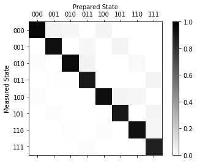

```python
meas_fitter = CompleteMeasFitter(cal_results, state_labels, circlabel='mcal')
# Gráfico da matriz de calibração
meas_fitter.plot_calibration()
```

### Análise dos resultados

```python
# Verificação de qual é a fidelidade da medição
print("Average Measurement Fidelity: %f" % meas_fitter.readout_fidelity())
```

```
Average Measurement Fidelity: 0.926514
```

### Aplicação da calibração

Vamos agora computar os resultados com erros de mitigação e sem erros de mitigação para pode comparar os resultados.  
Há dois metodos para aplicar a calibração:

- **pseudo_inverse:** Inverte a direção da matrix de calibração;
- **east_squares:** Restringe a probabilidades fisicas;

Se não for especificado qual queremo usar é usado *por default* o _least*squares*.

Os dados podem ser fornecidos de varias maneiras:

- Um dicionario com resultados: **results.get_counts**;
- O comprimento de uma lista de resultados: lenght=**len(state_labels)**;
- O comprimento de uma lista de resultados: length=**M*len(state_labels)** onde M é um inteiro;
- Um resultado do **Qiskit**;

```python
# Obter o objeto do filtro
meas_filter = meas_fitter.filter
# Resultados com mitigação
mitigated_results = meas_filter.apply(result_r)
mitigated_counts = mitigated_results.get_counts()
```

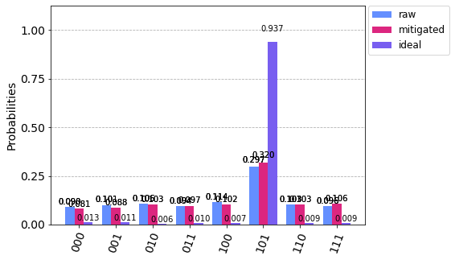

```python
plot_histogram([counts_run, mitigated_counts, results.get_counts(qc)], legend=['raw', 'mitigated', 'ideal'])
```

É possível concluir que os resultados estão um pouco melhores, contudo ainda estão longe do ideal.

```python
%qiskit_version_table
```

Version Information

| Qiskit Software | Version |
| --- | --- |
| Qiskit | 0.25.2 |
| Terra | 0.17.1 |
| Aer | 0.8.1 |
| Ignis | 0.6.0 |
| Aqua | 0.9.1 |
| IBM Q Provider | 0.12.3 |
| System information |  |
| Python | 3.8.8 (default, Apr 13 2021, 12:59:45) [Clang 10.0.0 ] |
| OS | Darwin |
| CPUs | 4 |
| Memory (Gb) | 16.0 |
| Sat Jun 05 17:19:22 2021 WEST |  |

Créditos: https://qiskit.org/documentation/locale/pt_BR/tutorials/circuits_advanced/04_transpiler_passes_and_passmanager.html